# Linear Models

Jolien Cremers (adapted from Gerko Vink)

Statistical Programming with R

# The linear model

## This Lecture:

- Linear models in R
- Checking assuptions
- Model fit & comparison
- Predictions

## I use the following packages in this lecture

```r
library(magrittr) #for pipes
library(mice)     #for the boys data
library(Ecdat)    #for the Benefits data
library(ggplot2)
```

## The linear model

The function `lm()` is a base function in `R` and allows you to pose a variety of linear models.

```r
args(lm)
```

```
## function (formula, data, subset, weights, na.action, method = "qr",
##     model = TRUE, x = FALSE, y = FALSE, qr = TRUE, singular.ok = TRUE,
##     contrasts = NULL, offset, ...)
## NULL
```

If we want to know what these arguments do we can ask R:

```r
?lm
```

This will open a help page on the `lm()` function.

## Benefits data

Unemployment of blue collar workers:

Column `stateur`:

- state unemployment rate (in %)

Column `tenure`:

- years of tenure in jobs lost

Column `age`:

- age in years

## Linear regression

Linear regression model
$$y_i=\alpha+\beta{x}_i+\varepsilon_i$$

Assumptions:

- $y_i$ conditionally normal with mean $\mu_i=\alpha+\beta{x}_i$
- $\varepsilon_i$ are $i.i.d.$ with mean 0 and (constant) variance $\sigma^2$

## Continuous predictors

To obtain a linear regression model with a main effect for `tenure`, we formulate $stateur\sim tenure$

```r
fit <- Benefits %$%
  lm(stateur~tenure)
fit
```

```
##
## Call:
## lm(formula = stateur ~ tenure)
##
## Coefficients:
## (Intercept)       tenure
##    7.460299     0.008957
```

## Continuous predictors: more detail

```r
fit %>% summary
```

```
##
## Call:
## lm(formula = stateur ~ tenure)
##
## Residuals:
##     Min      1Q  Median      3Q     Max
## -5.2693 -1.8051 -0.3693  1.4770 10.5307
##
## Coefficients:
##             Estimate Std. Error t value Pr(>|t|)
## (Intercept) 7.460299   0.048214 154.732   <2e-16 ***
## tenure      0.008957   0.005701   1.571    0.116
## ---
## Signif. codes:  0 '***' 0.001 '**' 0.01 '*' 0.05 '.' 0.1 ' ' 1
##
## Residual standard error: 2.5 on 4875 degrees of freedom
## Multiple R-squared:  0.000506,   Adjusted R-squared:  0.000301
## F-statistic: 2.468 on 1 and 4875 DF,  p-value: 0.1163
```

## Continuous predictors

To obtain a linear model with just main effects for `tenure` and `age`, we formulate $stateur\sim tenure + age$

```r
require(mice)
fit <- Benefits %$%
  lm(stateur ~ tenure + age)
fit
```

```
##
## Call:
## lm(formula = stateur ~ tenure + age)
##
## Coefficients:
## (Intercept)       tenure          age
##     7.91128      0.02072     -0.01433
```

## Continuous predictors: more detail

```r
fit %>% summary
```

```
##
## Call:
## lm(formula = stateur ~ tenure + age)
##
## Residuals:
##     Min      1Q  Median      3Q     Max
## -5.3165 -1.8217 -0.3982  1.4691 10.7142
##
## Coefficients:
##              Estimate Std. Error t value Pr(>|t|)
## (Intercept)  7.911283   0.130724  60.519  < 2e-16 ***
## tenure       0.020721   0.006517   3.179 0.001485 **
## age         -0.014327   0.003861  -3.711 0.000209 ***
## ---
## Signif. codes:  0 '***' 0.001 '**' 0.01 '*' 0.05 '.' 0.1 ' ' 1
##
## Residual standard error: 2.497 on 4874 degrees of freedom
## Multiple R-squared:  0.003322,   Adjusted R-squared:  0.002913
## F-statistic: 8.122 on 2 and 4874 DF,  p-value: 0.0003009
```

## Continuous predictors: interaction effects

To obtain a linear model with an interaction effect for `tenure` and `age`, we formulate $stateur\sim tenure * age$

```r
fit <- Benefits %$% lm(stateur ~ tenure * age)
```

Equivalent

```r
fit <- Benefits %$% lm(stateur ~ tenure + age + tenure:age)
```

## Continuous predictors: interaction effects

```r
fit
```

```
##
## Call:
## lm(formula = stateur ~ tenure * age)
##
## Coefficients:
## (Intercept)       tenure          age   tenure:age
##    7.686119     0.076781    -0.009180    -0.001174
```

## and with more detail

```r
fit %>% summary
```

```
##
## Call:
## lm(formula = stateur ~ tenure * age)
##
## Residuals:
##     Min      1Q  Median      3Q     Max
## -5.4060 -1.8214 -0.3735  1.4856 10.6933
##
## Coefficients:
##               Estimate Std. Error t value Pr(>|t|)
## (Intercept)  7.6861194  0.1708825  44.979  < 2e-16 ***
## tenure       0.0767806  0.0281768   2.725  0.00645 **
## age         -0.0091803  0.0046074  -1.992  0.04637 *
## tenure:age  -0.0011741  0.0005742  -2.045  0.04091 *
## ---
## Signif. codes:  0 '***' 0.001 '**' 0.01 '*' 0.05 '.' 0.1 ' ' 1
##
## Residual standard error: 2.496 on 4873 degrees of freedom
## Multiple R-squared:  0.004176,   Adjusted R-squared:  0.003563
## F-statistic: 6.812 on 3 and 4873 DF,  p-value: 0.0001405
```

## Categorical predictors in the linear model

If a categorical variable is entered into function `lm()`, it is automatically converted to a dummy set in `R`. The first level is always taken as the reference category. If we want another reference category we can use the function `relevel()` to change this.

```r
fit_c <- Benefits %$% lm(stateur ~ joblost)
```

## and again with more detail

```r
fit_c %>% summary
```

```
##
## Call:
## lm(formula = stateur ~ joblost)
##
## Residuals:
##     Min      1Q  Median      3Q     Max
## -5.4848 -1.8062 -0.4062  1.5152 10.6806
##
## Coefficients:
##                           Estimate Std. Error t value Pr(>|t|)
## (Intercept)                7.36412    0.05615 131.161  < 2e-16 ***
## joblostposition_abolished -0.04472    0.13656  -0.327    0.743
## joblostseasonal_job_ended -0.05790    0.19582  -0.296    0.767
## joblostslack_work          0.32072    0.07639   4.199 2.73e-05 ***
## ---
## Signif. codes:  0 '***' 0.001 '**' 0.01 '*' 0.05 '.' 0.1 ' ' 1
##
## Residual standard error: 2.496 on 4873 degrees of freedom
## Multiple R-squared:  0.004427,   Adjusted R-squared:  0.003814
## F-statistic: 7.223 on 3 and 4873 DF,  p-value: 7.81e-05
```

## Components of the linear model

```r
names(fit_c) # the names of the list with output objects
```

```
##  [1] "coefficients"  "residuals"     "effects"       "rank"
##  [5] "fitted.values" "assign"        "qr"            "df.residual"
##  [9] "contrasts"     "xlevels"       "call"          "terms"
## [13] "model"
```

```r
fit_c$coef  # show the estimated coefficients
```

```
##               (Intercept) joblostposition_abolished
##                7.36411943               -0.04471645
## joblostseasonal_job_ended         joblostslack_work
##               -0.05790474                0.32072122
```

```r
coef(fit_c) # alternative
```

[output not shown]

# Checking assumptions

## Linearity

```r
Benefits %>%
  ggplot(aes(tenure, stateur)) +
  geom_point() +
  geom_smooth(method = "loess", col = "blue") +
  geom_smooth(method = "lm", col = "orange")
```

## Linearity

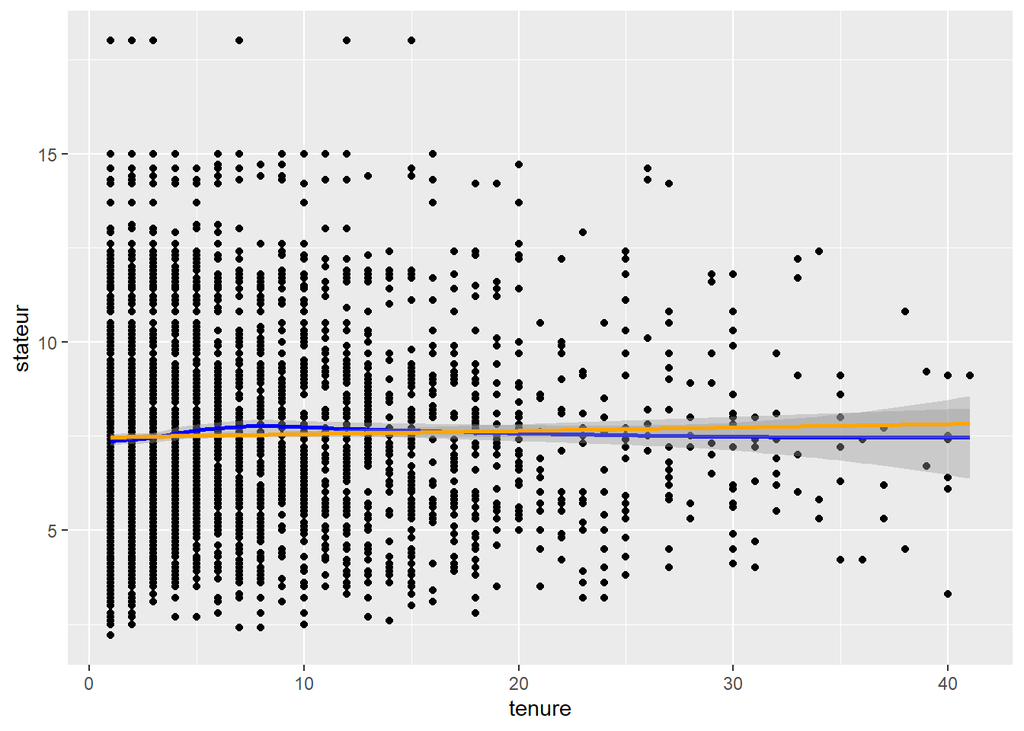

The loess curve suggests slight non-linearity

## Adding a squared term

```r
Benefits %$%
  lm(stateur ~ tenure + I(tenure^2)) %>%
  summary()
```

```
##
## Call:
## lm(formula = stateur ~ tenure + I(tenure^2))
##
## Residuals:
##     Min      1Q  Median      3Q     Max
## -5.2209 -1.8143 -0.3809  1.4551 10.5938
##
## Coefficients:
##               Estimate Std. Error t value Pr(>|t|)
## (Intercept)  7.3648387  0.0619654 118.854  < 2e-16 ***
## tenure       0.0427128  0.0149071   2.865  0.00418 **
## I(tenure^2) -0.0013388  0.0005463  -2.451  0.01430 *
## ---
## Signif. codes:  0 '***' 0.001 '**' 0.01 '*' 0.05 '.' 0.1 ' ' 1
##
## Residual standard error: 2.499 on 4874 degrees of freedom
## Multiple R-squared:  0.001736,   Adjusted R-squared:  0.001326
## F-statistic: 4.238 on 2 and 4874 DF,  p-value: 0.01449
```

## Constant error variance?

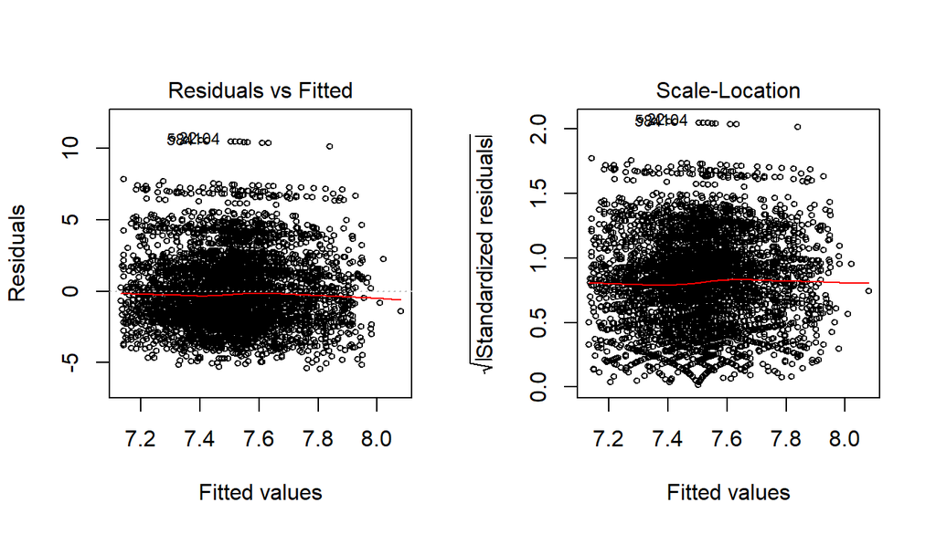

```r
par(mfrow = c(1, 2))
fit %>%
  plot(which = c(1, 3), cex = .6)
```

## No constant error variance!

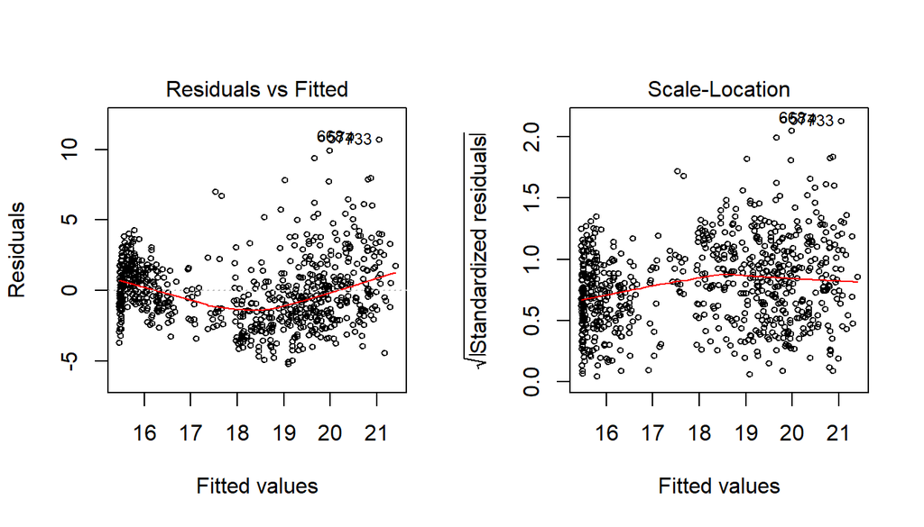

```r
par(mfrow = c(1, 2))
boys %$%
  lm(bmi ~ age) %>%
  plot(which = c(1, 3), cex = .6)
```

## Normality of errors

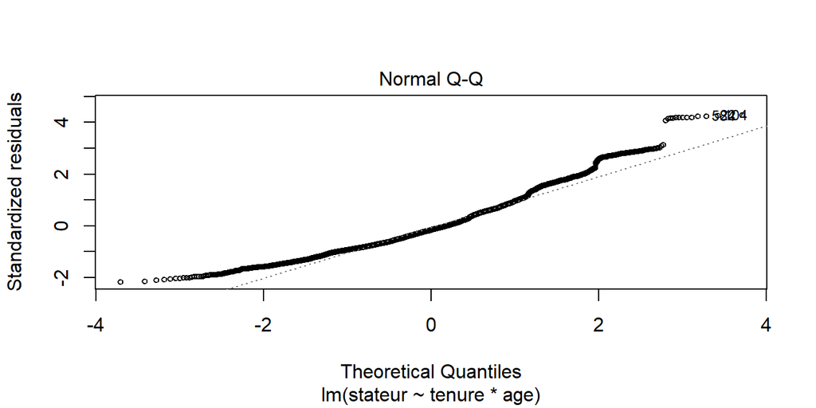

```r
fit %>%
  plot(which = 2, cex = .6)
```

The QQplot shows divergence from normality at the tails

## Histograms

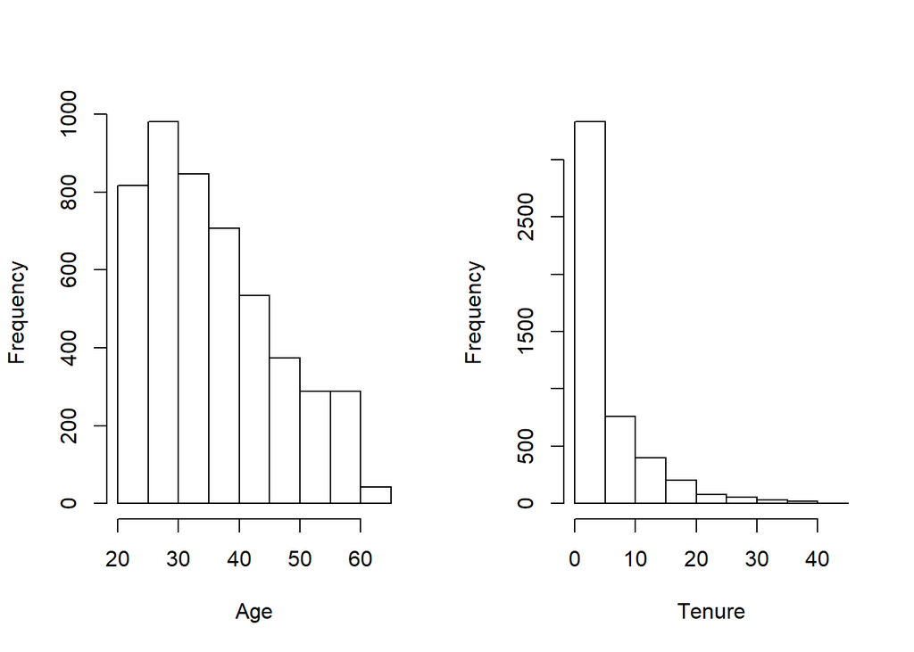

## Outliers and influential cases

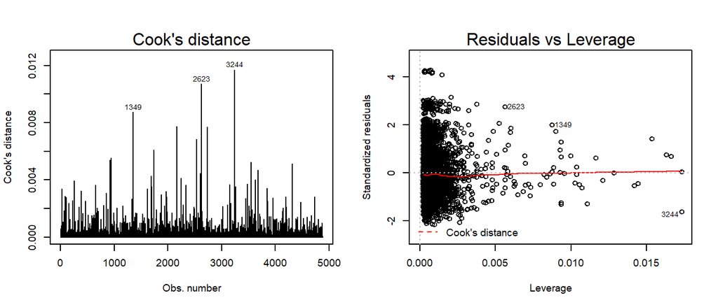

```r
par(mfrow = c(1, 2), cex = .6)
fit %>% plot(which = c(4, 5))
```

There are quite some cases with $|e_z|>2$ (right plot). There are no cases with Cook’s Distance $>1$, but some cases stand out.

## Fine

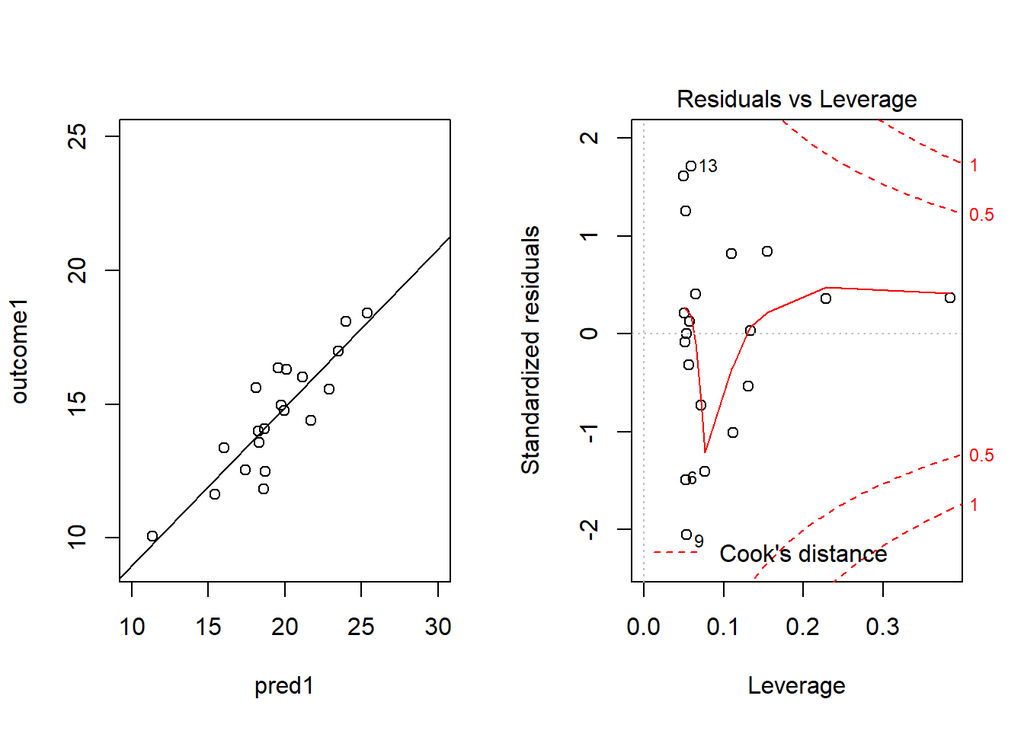

## High leverage, low residual

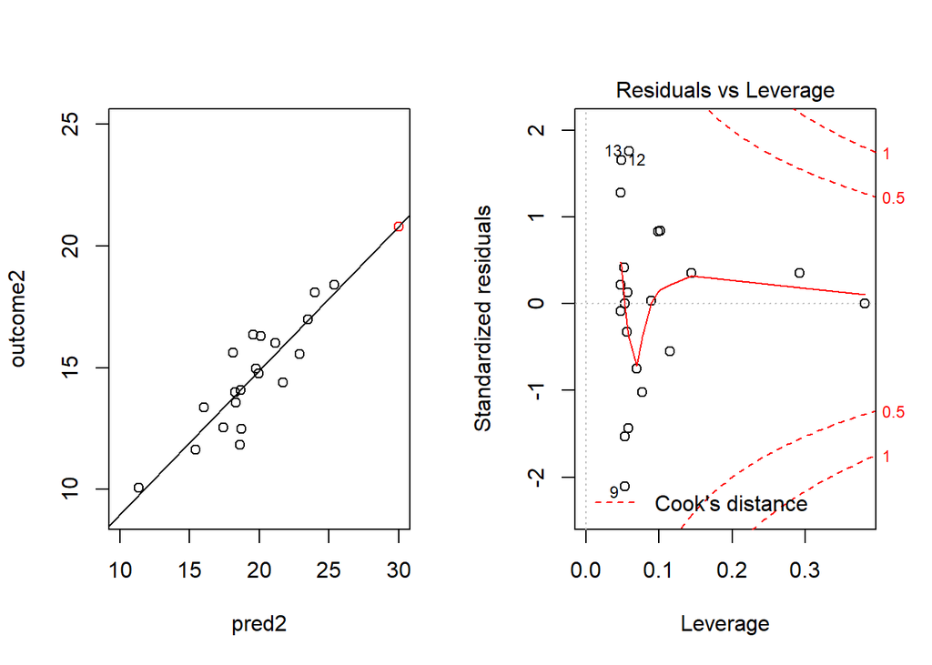

## Low leverage, high residual

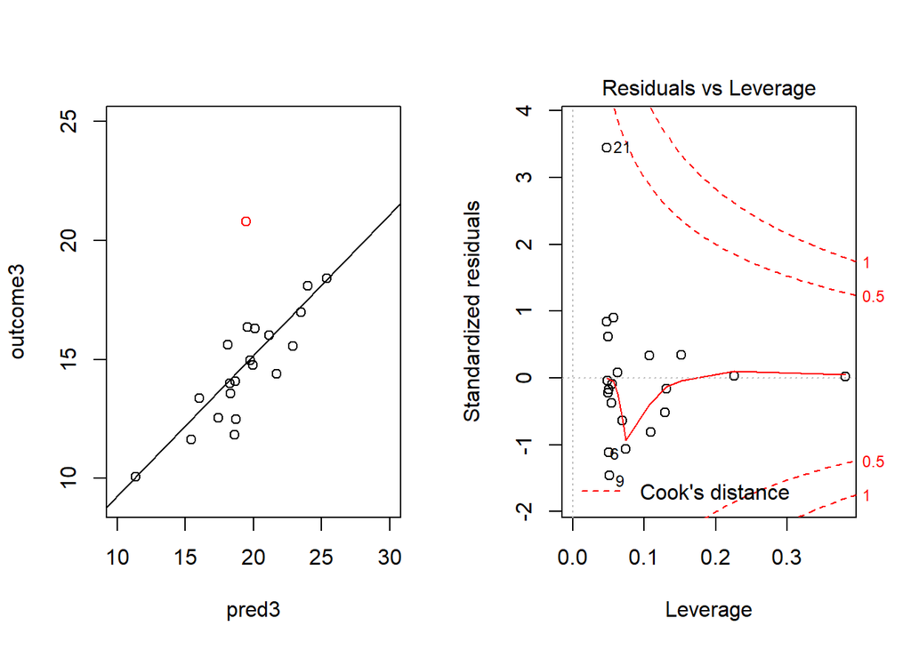

## High leverage, high residual

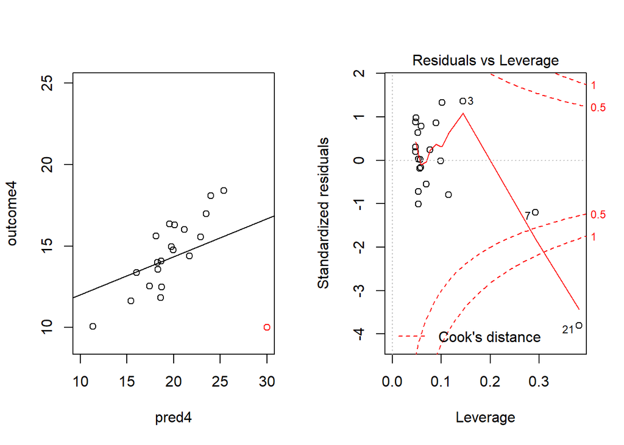

# Model fit & comparison

## R-squared

```r
summary(fit)$r.squared
```

```
## [1] 0.004176409
```

```r
summary(fit)$adj.r.squared
```

```
## [1] 0.003563343
```

## AIC and BIC

Akaike’s *An Information Criterion*

```r
fit %>%
  AIC()
```

```
## [1] 22768.67
```

and *Bayesian Information Criterion*

```r
fit %>%
  BIC()
```

```
## [1] 22801.13
```

## Influence of cases

DfBeta calculates the change in coefficients depicted as deviation in SE’s.

```r
fit %>%
  dfbeta() %>%
  head(n = 7)
```

```
##     (Intercept)        tenure           age    tenure:age
## 1  0.0007342916 -2.224502e-04  3.640706e-07 -5.582413e-07
## 2  0.0035452252 -2.717886e-04 -7.398838e-05  5.377732e-06
## 3  0.0006738846 -2.839800e-04 -9.192347e-06  4.750169e-06
## 4  0.0005261632  1.964583e-05 -1.336573e-05 -2.128578e-06
## 5 -0.0005698390  9.901239e-05  5.378984e-06 -1.579094e-06
## 6 -0.0002833433  1.905711e-06  1.062632e-05 -2.695563e-07
## 7 -0.0006480895 -1.443784e-04  1.228765e-05  2.737813e-06
```

# Prediction

## Fitted values:

Let’s use the simpler `anscombe` data example

```r
fit <- anscombe %$% lm(y1 ~ x1)
y_hat <-
  fit %>%
  fitted.values()
```

The residual is then calculated as

```r
y_hat - anscombe$y1
```

```
##           1           2           3           4           5           6
## -0.03900000  0.05081818  1.92127273 -1.30909091  0.17109091  0.04136364
##           7           8           9          10          11
## -1.23936364  0.74045455 -1.83881818  1.68072727 -0.17945455
```

## Predict new values

If we introduce new values for the predictor `x1`, we can generate predicted values from the model

```r
new.x1 <- data.frame(x1 = 1:20)
predict.lm(fit, newdata = new.x1)
```

```
##         1         2         3         4         5         6         7
##  3.500182  4.000273  4.500364  5.000455  5.500545  6.000636  6.500727
##         8         9        10        11        12        13        14
##  7.000818  7.500909  8.001000  8.501091  9.001182  9.501273 10.001364
##        15        16        17        18        19        20
## 10.501455 11.001545 11.501636 12.001727 12.501818 13.001909
```

## Predictions are draws from the regression line

```r
pred <- predict.lm(fit, newdata = new.x1)
lm(pred ~ new.x1$x1)$coefficients
```

```
## (Intercept)   new.x1$x1
##   3.0000909   0.5000909
```

```r
fit$coefficients
```

```
## (Intercept)          x1
##   3.0000909   0.5000909
```

## Prediction intervals

```r
predict(fit, interval = "prediction")
```

```
##          fit      lwr       upr
## 1   8.001000 5.067072 10.934928
## 2   7.000818 4.066890  9.934747
## 3   9.501273 6.390801 12.611745
## 4   7.500909 4.579129 10.422689
## 5   8.501091 5.531014 11.471168
## 6  10.001364 6.789620 13.213107
## 7   6.000636 2.971271  9.030002
## 8   5.000455 1.788711  8.212198
## 9   9.001182 5.971816 12.030547
## 10  6.500727 3.530650  9.470804
## 11  5.500545 2.390073  8.611017
```

## Some other modeling devices in `R`

- `lm()`: linear modeling
- `glm()`: generalized linear modeling
- `gamlss::gamlss`: generalized additive models (for location, scale and shape)
- `lme4::lmer`: linear mixed effect models
- `lme4::glmer`: generalized linear mixed effect models
- `lme4::nlmer`: non-linear mixed effect models